# Splendid Alfonsino Species Summary

NPFC Bottom Fisheries Small Working Group

2021-06-30

# Splendid Alfonsino (*Beryx splendens*)

## Biological Information

Global distribution ranges from tropical to temperate oceans. Historical catch records in the Emperor Seamount suggest the distribution from Nintoku (45 °N) to Hancock (30 °N). Settlement occurs following a certain period of the pelagic life stage. Adults show a vertical distribution from 200 to 800 m with diel vertical migration, feeding on crustaceans, cephalopods, and fish during the night. Limited information is available for recruitment and reproduction processes in the Emperor Seamounts, whereas the population in the Japanese coast shows 4–5 years to sexually mature and spawning occurs during summer.

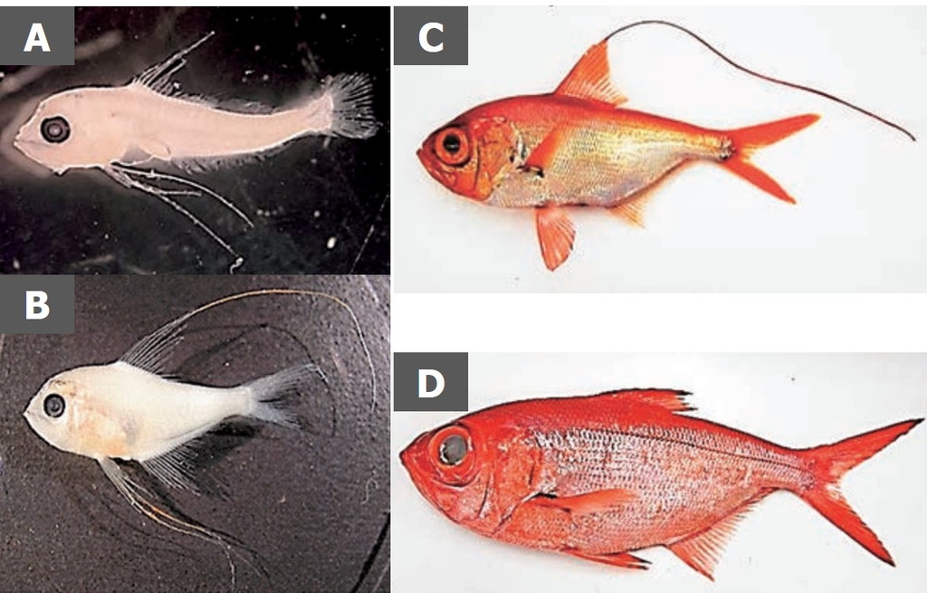

**Figure 1: Photographs of Beryx splendens.**  
A) postlarva, B) juvenile, C) young, D) adult (from Watari et al. 2016)

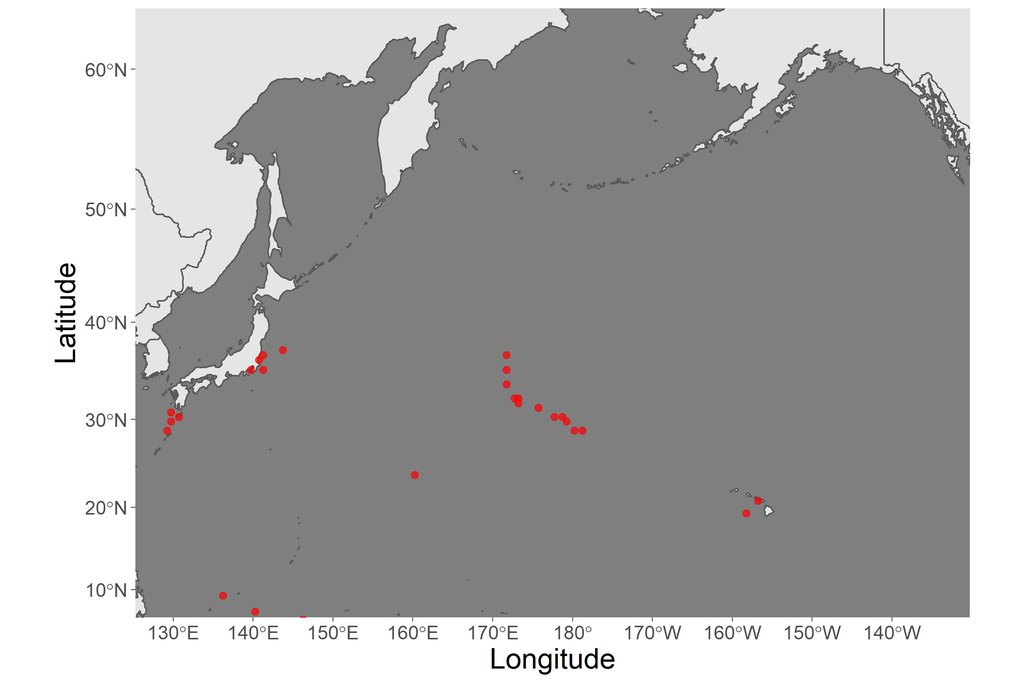

**Figure 2: Known distribution of Beryx splendens.**  
Points indicate observation data from original sources (AquaMaps 2019, October)

## Fishery

Since the discovery of large populations of North Pacific Armorhead (NPA) in the Emperor Seamount in the late 1960s, SA has been exploited as an alternative resource to NPA due to the large temporal fluctuation of the NPA population. The main fishing methods are bottom trawls and gillnets.

Size composition analysis from the catch data by Japanese trawlers suggests the substantial decrease in size of fish in catches over the past decade, raising the concern about recruitment overfishing.

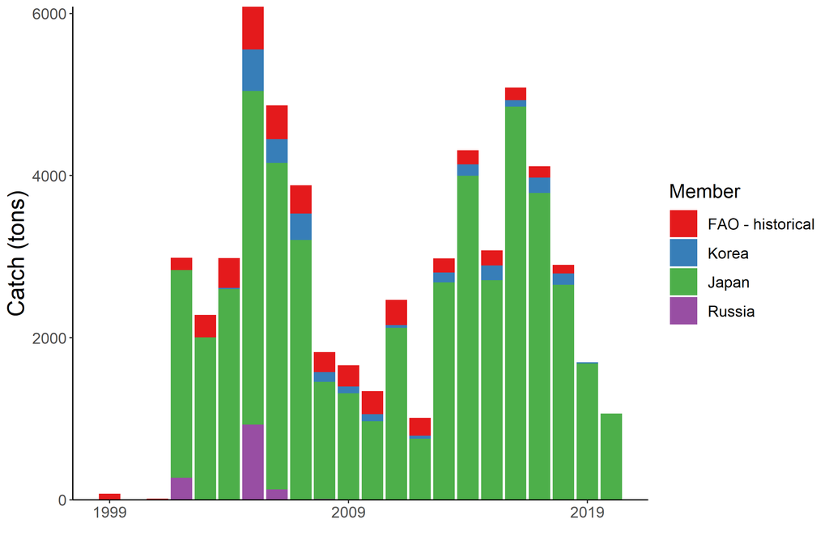

**Figure 3: Catch trends of splendid alfonsino over the past two decades.** The annual amounts of catch for alfonsino by each Member are shown by the bar plot.

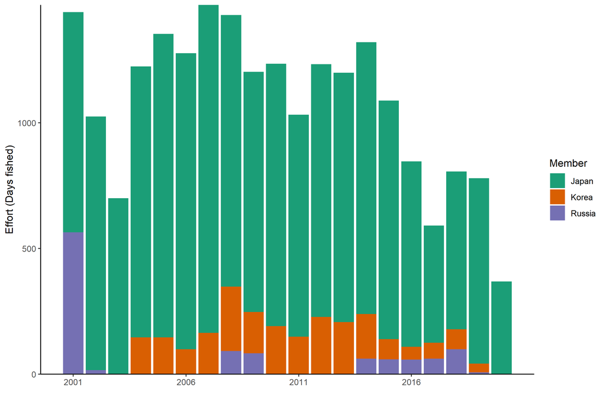

**Figure 4. Historical fishing effort for Splendid Alfonsino.**

## Assessment

There are no biomass estimates available for SA in NPFC waters.

Data limited approaches, such as YPR or SPR analysis that do not require detailed resource parameters or fishing data, should be explored in the future.

## Management

**Active Management Measures**

The following NPFMC conservation and management measures pertain to this species:

- CMM 2019-05 For Bottom Fisheries and Protection of VMEs in the NW Pacific Ocean
- CMM 2019-06 For Bottom Fisheries and Protection of VMEs in the NE Pacific Ocean

Available from https://www.npfc.int/active-conservation-and-management-measures

Management Summary

|  | Status | Comment |
| --- | --- | --- |
| Biological reference points | Not accomplished | Not established |
| Stock status | Unknown | Status determination criteria not established |
| Catch limit | Intermediate | Recommended catch, effort limits |
| Harvest control rule | Not accomplished | Not established |
| Other | Intermediate | No expansion of fishing beyond established areas |

Currently, there is no accepted harvest control for this species.

In 2016, the interim management measures were implemented, which includes limiting the fishing effort to the 2007’s catch level, prohibiting fisheries from November to December (which corresponds to the spawning season for NPA) and not allowing fisheries in C-H Seamount and the southeastern part of Koko Seamount (for the protection of VMEs).

In 2019, an adaptive management plan was additionally adopted, which includes the regulation of the mesh size (trawl: > 10 cm, gillnet: 12 cm) to protect juvenile fish. Still, this measure is insufficient as the substantial catch of young fish has been reported by trawlers even after being implemented.

## Data Summary

[output not shown]

## References

FAO. (2016). Global review of Alfonsino (Beryx spp.) their fisheries, biology, and management. In *Food and Agriculture Organization of the United Nations* (Vol. 1084, Issue 1084). http://www.fao.org/3/a-i5336e.pdf

Sawada, K., Nishida, K., Yonezaki, S., Kiyota, M., & Review, M. (2018). *Review of biology and fisheries of splendid alfonsino Beryx splendens , especially in the Emperor seamounts area by April 2018 This paper may be cited in the following manner: NPFC-2018-SSC BF01-WP03 Review of biology and fisheries of splendid alfonsino*.